```python
import numpy as np
from matplotlib import pyplot as plt
import scipy.stats as scistats
from collections import deque, Counter
import math
```

```python
class Network():
    def __init__(self,num_nodes):
        self.adj = {i:set() for i in range(num_nodes)}
        self.num_edge = 0

    def add_edge(self,i,j):
        self.adj[i].add(j)
        self.adj[j].add(i)
        self.num_edge+=1

    def neighbors (self,i):
        return self.adj[i]

    def edge_list(self):
        return [(i,j) for i in self.adj for j in self.adj[i] if i<j]
```

# Q1

Implement code to sample from the configuration models where degrees $k_i$ are sampled from a Poisson distribution and Geometric distribution.

For both cases, let $n$=10,000 and $<k> = 10$. Verify that the degree distribution approximately match the required PMF.

```python
class Poisson_Configuration_Network(Network):

    def __init__(self, num_nodes,mn=10):
        super().__init__(num_nodes)

        k = np.random.poisson(lam=mn,size=num_nodes)

        S = np.array([i for i in range(num_nodes) for _ in range(k[i])])
        S = np.random.permutation(S)

        if len(S)%2:
            S = S[:-1]

        S = S.reshape(-1,2)

        for i,j in S:
            if i!=j:
                self.add_edge(i,j)
```

```python
class Geometric_Configuration_Network(Network):

    def __init__(self, num_nodes, mn=10):
        super().__init__(num_nodes)

        k = np.random.geometric(1/(mn+1), size=num_nodes)

        S = np.array([i for i in range(num_nodes) for _ in range(k[i]-1)])
        S = np.random.permutation(S)

        if len(S)%2:
            S = S[:-1]

        S = S.reshape(-1,2)

        for i,j in S:
            if i!=j:
                self.add_edge(i,j)
```

```python
n = 10000
mn = 10

poisson_network = Poisson_Configuration_Network(n,mn)
geometric_network = Geometric_Configuration_Network(n,mn)

degree_dist_poisson = []
degree_dist_geometric = []

for i in range(n):

    degree_dist_poisson.append(len(poisson_network.neighbors(i)))
    degree_dist_geometric.append(len(geometric_network.neighbors(i)))
```

```
Sampled mean = 10.0384
```

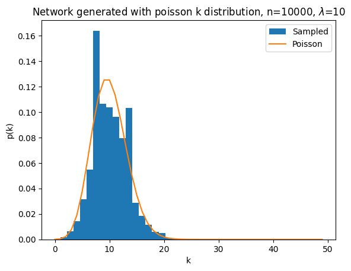

```python
k_range = [k for k in range(50)]

print('Sampled mean = {}'.format(np.mean(degree_dist_poisson)))

plt.hist(degree_dist_poisson,label='Sampled',density=True,bins=20)
plt.plot(k_range,scistats.poisson.pmf(k_range, mu=mn),label='Poisson')
plt.title(r'Network generated with poisson k distribution, n={}, $\lambda$={}'.format(n,mn))
plt.xlabel('k')
plt.ylabel('p(k)')
plt.legend()
plt.show()
```

```
Sampled mean = 9.8064
```

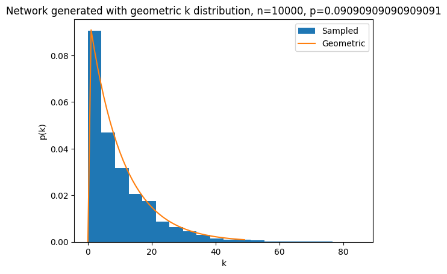

```python
k_range = [k for k in range(50)]

print('Sampled mean = {}'.format(np.mean(degree_dist_geometric)))

plt.hist(degree_dist_geometric,label='Sampled',density=True,bins=20)
plt.plot(k_range,scistats.geom.pmf(k_range,p=1/(mn+1)),label='Geometric')
plt.title('Network generated with geometric k distribution, n={}, p={}'.format(n,1/(mn+1)))
plt.xlabel('k')
plt.ylabel('p(k)')
plt.legend()
plt.show()
```

# Q2

The friendship paradox states that

$$<\kappa> \geq <k>$$

Meaning on average, people have fewer friends than their friends.

Verify the friendship paradox numerically by repeating the following :

1. Choose a node at random
2. Choose a neighbour of that node at random
3. Record both of their degrees

Finally, make a histogram of the degrees. Ignore nodes of degree 0.

```python
samples = 10000
n=10000

random_self = np.random.randint(0,n,size=samples)
poisson_self_k_array = []
poisson_friend_k_array = []
geom_self_k_array = []
geom_friend_k_array = []

for i in random_self:

    p_i = i
    g_i = i

    while not len(poisson_network.neighbors(p_i)):
        poisson_self_k_array.append(0)
        p_i = np.random.randint(0,n)

    poisson_friends =  poisson_network.neighbors(p_i)
    poisson_self_k_array.append(len(poisson_friends))
    poisson_friend_k_array.append(len(poisson_network.neighbors(np.random.choice(list(poisson_friends)))))

    while not len(geometric_network.neighbors(g_i)):
        geom_self_k_array.append(0)
        g_i = np.random.randint(0,n)

    geometric_friends = geometric_network.neighbors(g_i)
    geom_self_k_array.append(len(geometric_friends))
    geom_friend_k_array.append(len(geometric_network.neighbors(np.random.choice(list(geometric_friends)))))
```

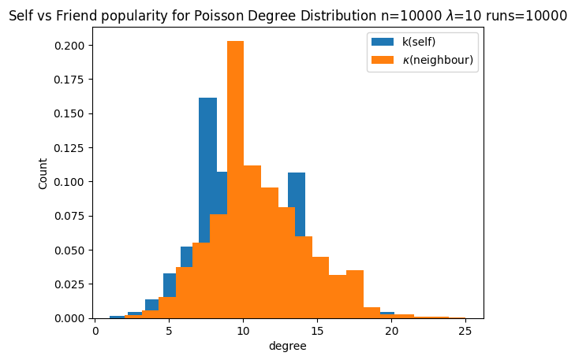

```
Mean of k(self) = 10.0924
Mean of $\kappa$(neighbour) = 11.0575
```

```python
Q4_poisson = poisson_friend_k_array

plt.hist(poisson_self_k_array,density=True,label='k(self)',bins=20)
plt.hist(poisson_friend_k_array,density=True,label=r'$\kappa$(neighbour)',bins=20)
plt.title(r'Self vs Friend popularity for Poisson Degree Distribution n={} $\lambda$={} runs={}'.format(n,mn,samples))
plt.xlabel('degree')
plt.ylabel('Count')
plt.legend()
plt.show()

mn_k_poisson = np.mean(poisson_self_k_array)
mn_kappa_poisson = np.mean(poisson_friend_k_array)

print('Mean of k(self) = {}'.format(mn_k_poisson))
print(r'Mean of $\kappa$(neighbour) = {}'.format(mn_kappa_poisson))
```

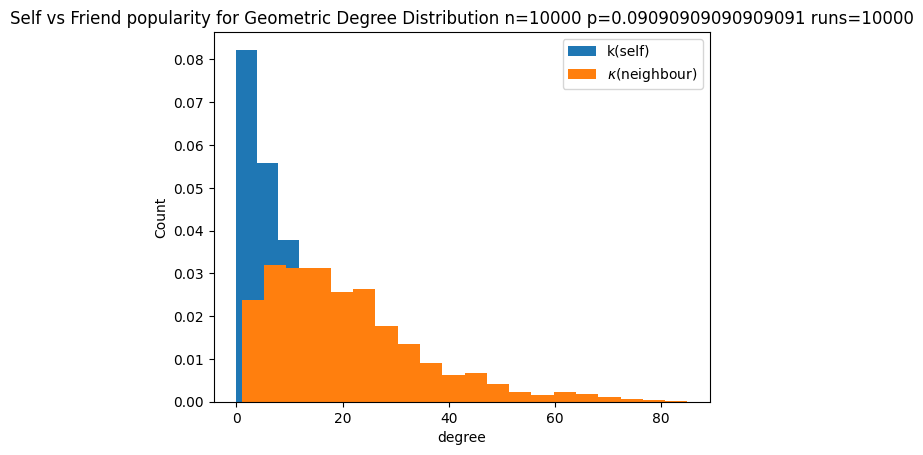

```
Mean of k(self) = 9.765343939256983
Mean of $\kappa$(neighbour) = 20.8821
```

```python
Q4_geom = geom_friend_k_array

plt.hist(geom_self_k_array,density=True,label='k(self)',bins=20)
plt.hist(geom_friend_k_array,density=True,label=r'$\kappa$(neighbour)',bins=20)
plt.title('Self vs Friend popularity for Geometric Degree Distribution n={} p={} runs={}'.format(n,1/(mn+1),samples))
plt.xlabel('degree')
plt.ylabel('Count')
plt.legend()
plt.show()

mn_k_geom = np.mean(geom_self_k_array)
mn_kappa_geom =np.mean(geom_friend_k_array)

print('Mean of k(self) = {}'.format(mn_k_geom))
print(r'Mean of $\kappa$(neighbour) = {}'.format(mn_kappa_geom))
```

# Q3

Make a histogram for

$$\Delta_{i}= \kappa_{i} - k_{i}$$

Show that the mean is larger than 0

If degree(i) = 0 , the degree difference is 0

```python
samples = 500
n = 10000

random_self = np.random.randint(0,n,size=samples)
poisson_self_k_array = []
poisson_delt_k_avg_array = []
geom_self_k_array = []
geom_delt_k_avg_array = []

for i in random_self:

    p_i = i
    g_i = i

    while len(poisson_network.neighbors(p_i))==0:
        poisson_delt_k_avg_array.append(0)
        p_i = np.random.randint(0,n)

    poisson_friends =  poisson_network.neighbors(p_i)
    poisson_self_k_array.append(len(poisson_friends))
    poisson_friend_k_array = []

    for j in poisson_friends:
        poisson_friend_k_array.append(len(poisson_network.neighbors(j)))

    poisson_delt_k_avg_array.append(np.mean(poisson_friend_k_array)-len(poisson_friends))


    while len(geometric_network.neighbors(g_i))==0:
        geom_delt_k_avg_array.append(0)
        g_i = np.random.randint(0,n)

    geometric_friends = geometric_network.neighbors(g_i)
    geom_self_k_array.append(len(geometric_friends))
    geom_friend_k_array = []

    for j in geometric_friends:
        geom_friend_k_array.append(len(geometric_network.neighbors(j)))

    geom_delt_k_avg_array.append(np.mean(geom_friend_k_array)-len(geometric_friends))
```

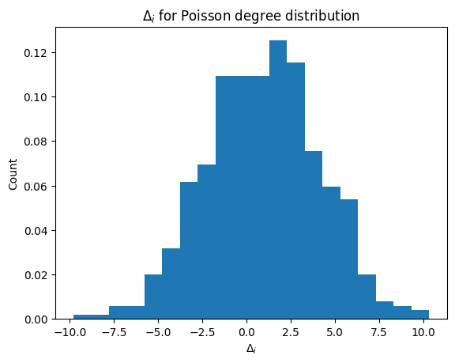

```
Mean $\Delta_i$ = 0.9039799112823881
```

```python
plt.hist(poisson_delt_k_avg_array,density=True,bins=20)
plt.xlabel(r'$\Delta_{i}$')
plt.ylabel('Count')
plt.title(r'$\Delta_{i}$ for Poisson degree distribution')
plt.show()

print(r'Mean $\Delta_i$ = {}'.format(np.mean(poisson_delt_k_avg_array)))
```

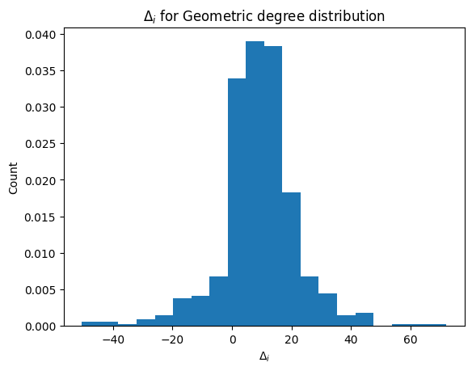

```
Mean $\Delta_i$ = 8.963494405125353
```

```python
plt.hist(geom_delt_k_avg_array,density=True,bins=20)
plt.xlabel(r'$\Delta_{i}$')
plt.ylabel('Count')
plt.title(r'$\Delta_{i}$ for Geometric degree distribution')
plt.show()

print(r'Mean $\Delta_i$ = {}'.format(np.mean(geom_delt_k_avg_array)))
```

# Q4

Proof of $q_{k}$ :

Assume that we randomly pick a vertex and assume this vertex has degree bigger than 0. What is the probability that a randomly chosen neighbour of this vertex having degree k? This does not follow $p_{k}$ since we know for sure that our vertex has degree of at least one, and hence any non-zero $p_{0}$ will be at odds with this fact. Note that a network has in total $2m$ half-edges. Such that $2m = \sum(k_{i})$. For a neighbour of degree k, there are k half-edges along which we can approach this neighbour, and the total number of half-edges (excluding the edge followed initially to get to the random vertex) is 2m-1. The total number of such neighbours in the network is $n_{k} = p_{k}*n$. Therefore

$$q_{k} = \frac{k*n*p_{k}}{2m-1} \approx \frac{k*n*p_{k}}{2m} = \frac{k*p_{k}}{\sum_{k'}k'p_{k'}} $$

Source : https://www.ndsu.edu/pubweb/~novozhil/Teaching/767%20Data/47_pdfsam_notes.pdf

https://sites.santafe.edu/~aaronc/courses/5352/fall2013/csci5352_2013_L12.pdf

## NOTE : Derive equation of mean degree and mean excess degree in terms of variance of degree distribution

```python
n=10000
mn = 10
k_range = [k for k in range(70)]

mean, var = scistats.poisson.stats(mu = mn, moments='mv')

poisson_excess_pmf = [k*p/mean for k,p in zip(k_range,scistats.poisson.pmf(k_range, mu=mn))]
```

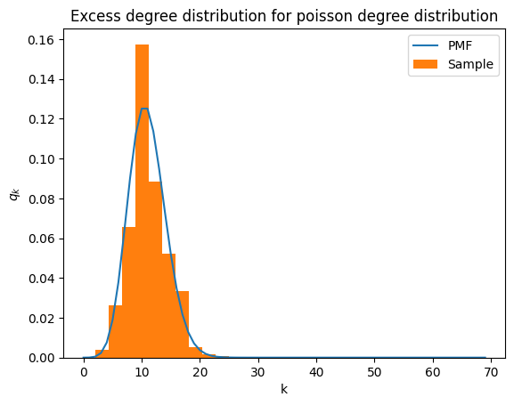

```python
plt.plot(k_range,poisson_excess_pmf,label="PMF")
plt.hist(Q4_poisson,density=True,label='Sample')
plt.title('Excess degree distribution for poisson degree distribution')
plt.xlabel('k')
plt.ylabel(r'$q_{k}$')
plt.legend()
plt.show()
```

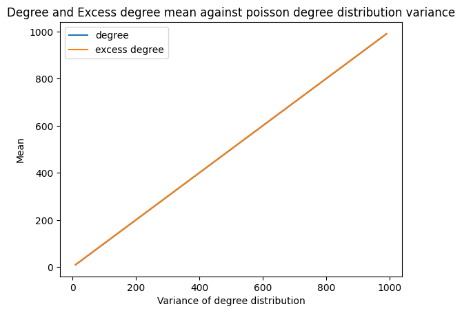

```python
poisson_lambda_range = np.arange(10,1000,10)
p_mean_array=[]
p_excess_mean_array=[]

for lam in poisson_lambda_range:

    p_mean, var = scistats.poisson.stats(mu=lam, moments='mv')
    p_mean_array.append(p_mean)

    p_excess_mean_array.append(scistats.poisson.expect(lambda k: k**2/p_mean,(lam,)))

plt.plot(poisson_lambda_range,p_mean_array,label='degree')
plt.plot(poisson_lambda_range,p_excess_mean_array,label='excess degree')
plt.title('Degree and Excess degree mean against poisson degree distribution variance')
plt.xlabel('Variance of degree distribution')
plt.ylabel('Mean')
plt.legend()
plt.show()
```

```python
mn = 10
n = 10000
k_range = [k for k in range(70)]

mean, var = scistats.geom.stats(p = 1/(mn+1), moments='mv')

geom_excess_pmf = [k*p/mean for k,p in zip(k_range,scistats.geom.pmf(k_range, p=1/(mn+1)))]
```

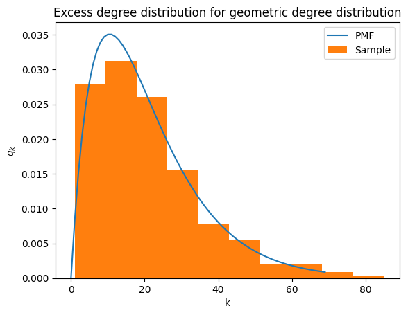

```python
plt.plot(k_range,geom_excess_pmf,label='PMF')
plt.hist(Q4_geom,density=True,label='Sample')
plt.title('Excess degree distribution for geometric degree distribution')
plt.xlabel('k')
plt.ylabel(r'$q_{k}$')
plt.legend()
plt.show()
```

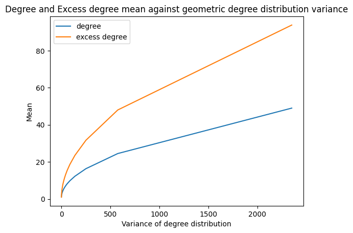

```python
geom_p_range = np.linspace(0,1,50)
g_mean_array=[]
g_var_array=[]
g_excess_mean_array=[]

for p in geom_p_range:

    g_mean, var = scistats.geom.stats(p=p, moments='mv')
    g_mean_array.append(g_mean)
    g_var_array.append(var)

    g_excess_mean_array.append(scistats.geom.expect(lambda k: k**2/g_mean,(p,)))

plt.plot(g_var_array,g_mean_array,label='degree')
plt.plot(g_var_array,g_excess_mean_array,label='excess degree')
plt.title('Degree and Excess degree mean against geometric degree distribution variance')
plt.xlabel('Variance of degree distribution')
plt.ylabel('Mean')
plt.legend()
plt.show()
```

# Q5

Poisson

$$ \sum_{k} z^{k} q_{k} = ze^{\lambda (z-1)}$$

Mean of excess degree = $\lambda$ + 1 Mean of degree = $\lambda$

Geometric $$ \sum_{k} z^{k} q_{k} = \frac{zp^{2}}{(1-(1-p)z)^{2}} $$

Mean of excess degree = $\frac{(2-p)}{p}$ Mean of degree = $\frac{1-p}{p}$

Showing that mean of excess degree is always > mean of degree

Relate the above to the friendship paradox https://www.stat.auckland.ac.nz/~fewster/325/notes/ch4.pdf

# Q6

https://nms.kcl.ac.uk/reimer.kuehn/published/GCPaper.pdf

Generate Poisson/Geometric graphs with mean degrees between [0,2]. Investigate the size of the component of an arbitrary node. Prove that the component size starts to grow earlier for the geometric degree distribution than for the poisson distribution.

The current expectation is that large components start to present themself when the mean excess degree is >1.

Analytic prediction for when large components start forming.

For poisson :

$$mean = \lambda > 1$$

For geometric :

$$\frac{2-p}{p}>1$$

but previously in week 1. We realised that large components only start presenting themselves when the mean degree > 1. This here provides a tighter bound. So we solve $$\frac{1-p}{p}>1-\frac{1}{p}$$

and we obtain $mean>0.5$

```python
def BFS(node,network: Network) -> int:
    q = deque([node])
    visited = set()
    count = 1

    while q:
        curr = q.popleft()

        for adj in network.neighbors(curr):
            if adj not in visited:
                count+=1
                visited.add(adj)
                q.append(adj)

    return count
```

```python
runs = 50

n=10000
means = np.linspace(0,2,30)
p_comp_size_array = []

for mn in means:
    comp_size = 0
    for _ in range(runs):
        p_network = Poisson_Configuration_Network(n,mn)
        comp_size+=BFS(np.random.randint(0,n),p_network)

    p_comp_size_array.append(comp_size/runs)
```

```python
runs = 50

n = 10000
g_comp_size_array = []

for mn in means:
    comp_size = 0
    for _ in range(runs):
        g_network = Geometric_Configuration_Network(n,mn)
        comp_size += BFS(np.random.randint(0,n),g_network)

    g_comp_size_array.append(comp_size/runs)
```

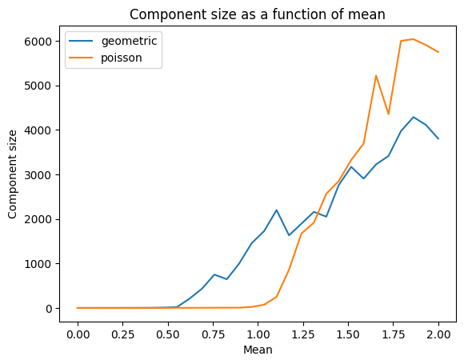

```python
plt.plot(means,g_comp_size_array,label='geometric')
plt.plot(means,p_comp_size_array,label='poisson')
plt.xlabel('Mean')
plt.ylabel('Component size')
plt.title('Component size as a function of mean')
plt.legend()
plt.show()
```

Simulation result shows that large components start to appear around mean = 0.5 for geometric and mean =1.0 for poisson.

# Q7

The current assumption is that the degrees of neighbours are uncorrelated

Simulation :

Generate a graph. Choose set of nodes. Record excess degree of it's neighbours. Plot function of x = k , y = skew of excess degree

Analytical :

Show that given k, q_k is a function of k

```python
runs = 5
n = 10000
lam = 10
p_ks = []
p_skews = []
p_ex_means = []
p_means=[]

for _ in range(runs):
    p_network = Poisson_Configuration_Network(n,lam)

    nodes = np.random.randint(0,n,50)

    for node in nodes:

        while (len(p_network.neighbors(node))==0):
            node = np.random.randint(0,n)
            p_means.append(0)

        friend_k_array = []

        for adj in p_network.neighbors(node):
            friend_k_array.append(len(p_network.neighbors(adj)))

        p_ks.append(len(p_network.neighbors(node)))
        p_means.append(len(p_network.neighbors(node)))
        tmp = scistats.skew(friend_k_array)
        p_skews.append(tmp if not math.isnan(tmp) else 0)
        p_ex_means.append(np.mean(friend_k_array))
```

```python
runs = 5
n = 10000
mn = 10
g_ks = []
g_skews = []
g_means=[]
g_ex_means = []

for _ in range(runs):
    g_network = Geometric_Configuration_Network(n,mn)

    nodes = np.random.randint(0,n,50)

    for node in nodes:

        while (len(g_network.neighbors(node))==0):
            node = np.random.randint(0,n)
            g_means.append(0)

        friend_k_array = []

        for adj in g_network.neighbors(node):
            friend_k_array.append(len(g_network.neighbors(adj)))

        g_ks.append(len(g_network.neighbors(node)))
        g_means.append(len(g_network.neighbors(node)))
        tmp = scistats.skew(friend_k_array)
        g_skews.append(tmp if not math.isnan(tmp) else 0)
        g_ex_means.append(np.mean(friend_k_array))
```

For a configuration network, the degree distributions are indeed uncorrelated.

We now explore the skew as a function of k. By allowing a 'popular' person to more likely be friends with other 'popular' people.

We also inspect mean of degree and mean of excess degree for such a network each for a Poisson and Geometric Degree distribution.

We form the 'biased' configuration network by first generating the degree distribution as usual. Then split the list of nodes into a 'popular' half and 'loner' half. Then we pair the nodes in each half. Finally, we perform a slight shuffle to the pairing.

```python
def split(arr):
    freq = Counter(arr)
    sorted_nodes = sorted(freq.items(),key= lambda item:item[1])

    loner = np.array([node for node,f in sorted_nodes[:len(sorted_nodes)//2] for _ in range(f)])
    popular = np.array([node for node,f in sorted_nodes[len(sorted_nodes)//2:] for _ in range(f)])

    return popular,loner
```

```python
def shuffle(arr: np.array, shuffle_factor):
    times = int(shuffle_factor*arr.shape[0])

    for _ in range(times):
        i,j = np.random.randint(0,arr.shape[0],size=2)

        arr[i][0], arr[j][0] = arr[j][0], arr[i][0]

    return arr
```

```python
class Biased_Poisson_Config_Network(Network):

    def __init__(self, num_nodes,mn,shuffle_factor=0.3):
        super().__init__(num_nodes)

        k = np.random.poisson(lam=mn,size=num_nodes)

        S = np.array([i for i in range(num_nodes) for _ in range(k[i])])
        S = np.random.permutation(S)

        popular, loner = split(S)

        if len(popular)%2:
            popular = popular[:-1]

        popular = popular.reshape(-1,2)

        if len(loner)%2:
            loner = loner[:-1]

        loner = loner.reshape(-1,2)

        S = np.concatenate((popular,loner),axis=0)

        S = shuffle(S,shuffle_factor)

        for i,j in S:
            if i!=j:
                self.add_edge(i,j)
```

```python
class Biased_Geometric_Config_Network(Network):

    def __init__(self, num_nodes,mn,shuffle_factor=0.3):
        super().__init__(num_nodes)

        k = np.random.geometric(1/(mn+1), size=num_nodes)

        S = np.array([i for i in range(num_nodes) for _ in range(k[i]-1)])
        S = np.random.permutation(S)

        popular, loner = split(S)

        if len(popular)%2:
            popular = popular[:-1]

        popular = popular.reshape(-1,2)

        if len(loner)%2:
            loner = loner[:-1]

        loner = loner.reshape(-1,2)

        S = np.concatenate((popular,loner),axis=0)

        S = shuffle(S,shuffle_factor)

        for i,j in S:
            if i!=j:
                self.add_edge(i,j)
```

```python
runs = 5
n = 10000
mn = 10
p_b_ks = []
p_b_skews = []
p_b_means = []
p_b_ex_means = []


for _ in range(runs):
    p_bias_network = Biased_Poisson_Config_Network(n,mn,shuffle_factor=0.1)

    nodes = np.random.randint(0,n,50)

    for node in nodes:

        while (len(p_bias_network.neighbors(node))==0):
            node = np.random.randint(0,n)
            p_b_means.append(0)

        friend_k_array = []

        for adj in p_bias_network.neighbors(node):
            friend_k_array.append(len(p_bias_network.neighbors(adj)))

        p_b_ks.append(len(p_bias_network.neighbors(node)))
        p_b_means.append(len(p_bias_network.neighbors(node)))
        p_b_skews.append(scistats.skew(friend_k_array))
        p_b_ex_means.append(np.mean(friend_k_array))
```

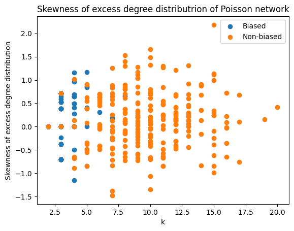

```python
plt.scatter(p_b_ks,p_b_skews, label='Biased')
plt.scatter(p_ks,p_skews, label='Non-biased')
plt.title('Skewness of excess degree distributrion of Poisson network')
plt.xlabel('k')
plt.ylabel('Skewness of excess degree distribution')
plt.legend()
plt.show()
```

Expect greater k to have more negative skew for biased network.

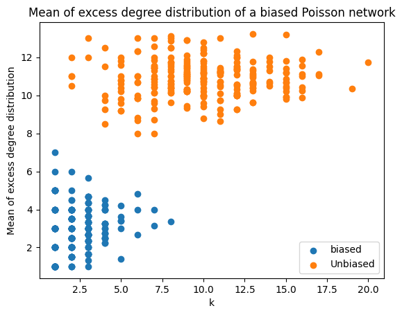

```python
plt.scatter(p_b_ks,p_b_ex_means, label='biased')
plt.scatter(p_ks,p_ex_means, label='Unbiased')
plt.title('Mean of excess degree distribution of a biased Poisson network')
plt.xlabel('k')
plt.ylabel('Mean of excess degree distribution')
plt.legend()
plt.show()
```

```python
print('Mean degree of node (Biased)= {}'.format(np.mean(p_b_means)))
print('Mean degree of node (Unbiased) = {}'.format(np.mean(p_means)))
print('Mean excess degree of unbiased = {}'.format(np.mean(p_ex_means)))
print('Mean excess degree of biased = {}'.format(np.mean(p_b_ex_means)))
print('Correlation of k and mean excess degree dist biased Poisson = {}'.format(scistats.pearsonr(p_b_ks,p_b_ex_means)[0]))
print('Correlation of k and mean excess degree dist unbiased Poisson = {}'.format(scistats.pearsonr(p_ks,p_ex_means)[0]))
```

```
Mean degree of node (Biased)= 2.1029411764705883
Mean degree of node (Unbiased) = 9.768
Mean excess degree of unbiased = 10.892906386802053
Mean excess degree of biased = 2.802404761904762
Correlation of k and mean excess degree dist biased Poisson = 0.27103681470458363
Correlation of k and mean excess degree dist unbiased Poisson = 0.049298718338919245
```

```python
runs = 5
n = 10000
mn = 10
g_b_ks = []
g_b_skews = []
g_b_means = []
g_b_ex_means = []


for _ in range(runs):
    g_bias_network = Biased_Geometric_Config_Network(n,mn,shuffle_factor=0.1)

    nodes = np.random.randint(0,n,50)

    for node in nodes:

        while (len(g_bias_network.neighbors(node))==0):
            node = np.random.randint(0,n)
            g_b_means.append(0)

        friend_k_array = []

        for adj in g_bias_network.neighbors(node):
            friend_k_array.append(len(g_bias_network.neighbors(adj)))

        g_b_ks.append(len(g_bias_network.neighbors(node)))
        g_b_means.append(len(g_bias_network.neighbors(node)))
        g_b_skews.append(scistats.skew(friend_k_array))
        g_b_ex_means.append(np.mean(friend_k_array))
```

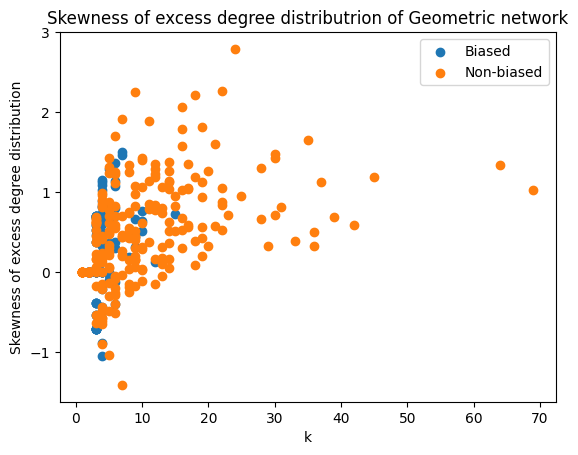

```python
plt.scatter(g_b_ks,g_b_skews, label='Biased')
plt.scatter(g_ks,g_skews, label='Non-biased')
plt.title('Skewness of excess degree distributrion of Geometric network')
plt.xlabel('k')
plt.ylabel('Skewness of excess degree distribution')
plt.legend()
plt.show()
```

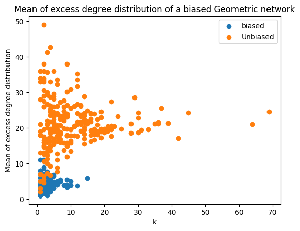

```python
plt.scatter(g_b_ks,g_b_ex_means, label='biased')
plt.scatter(g_ks,g_ex_means, label='Unbiased')
plt.title('Mean of excess degree distribution of a biased Geometric network')
plt.xlabel('k')
plt.ylabel('Mean of excess degree distribution')
plt.legend()
plt.show()
```

```python
print('Mean degree of node (Biased)= {}'.format(np.mean(g_b_means)))
print('Mean degree of node (Unbiased) = {}'.format(np.mean(g_means)))
print('Mean excess degree of unbiased = {}'.format(np.mean(g_ex_means)))
print('Mean excess degree of biased = {}'.format(np.mean(g_b_ex_means)))
print('Correlation of k and mean degree of biased Geom = {}'.format(scistats.pearsonr(g_b_ks,g_b_ex_means)[0]))
print('Correlation of k and mean degree of unbiased Geom = {}'.format(scistats.pearsonr(g_ks,g_ex_means)[0]))
```

```
Mean degree of node (Biased)= 2.2218430034129693
Mean degree of node (Unbiased) = 9.308823529411764
Mean excess degree of unbiased = 21.15054471716178
Mean excess degree of biased = 3.370242857142857
Correlation of k and mean degree of biased Geom = 0.33257297037252287
Correlation of k and mean degree of unbiased Geom = 0.03798720355000866
```